# Building consents issued — exploratory data analysis

## 3.6 The district × quarter frame for RQ1

RQ1 asks what drives the value per square metre of new houses across districts. Monthly district figures are too noisy — a small district may consent three houses one month and none the next — so the unit of analysis is the district-quarter. The 67 territorial authorities are kept; the area outside any TA is dropped. Quarters are formed from the month, and only complete quarters (three months present) are kept, which removes the partial 2026-Q3.

```r
districts <- df_ta %>%
  distinct(area) %>%
  filter(!area %in% c("New Zealand", "Area Outside Territorial Authority")) %>%
  pull(area)
length(districts)
```

```
## [1] 67
```

```r
ta_quarter <- df_ta %>%
  filter(area %in% districts, work == "New", building_type == "Houses") %>%
  mutate(year    = as.integer(substr(Period, 1, 4)),
         quarter = (as.integer(substr(Period, 6, 7)) - 1) %/% 3 + 1) %>%
  group_by(area, year, quarter, measure) %>%
  summarise(total = sum(Data_value), months = n(), .groups = "drop") %>%
  pivot_wider(id_cols = c(area, year, quarter, months), names_from = measure, values_from = total) %>%
  # keep complete quarters only
  filter(months == 3) %>%
  dplyr::select(-months) %>%
  rename(houses = Number, value = Value, floor_area = `Floor area`) %>%
  mutate(dollars_per_m2 = if_else(houses > 0 & floor_area > 0, value / floor_area, NA_real_),
         m2_per_house   = if_else(houses > 0, floor_area / houses, NA_real_))

ta_quarter %>%
  summarise(district_quarters = n(),
            districts         = n_distinct(area),
            quarters          = n_distinct(paste(year, quarter)),
            first_quarter     = paste0(min(year), "-Q", quarter[which.min(year * 10 + quarter)]),
            last_quarter      = paste0(max(year), "-Q", quarter[which.max(year * 10 + quarter)]),
            zero_houses       = scales::percent(mean(houses == 0), accuracy = 0.1),
            under_5_houses    = scales::percent(mean(houses < 5), accuracy = 0.1),
            at_least_5_houses = sum(houses >= 5)) %>%
  mutate(across(everything(), as.character)) %>%
  pivot_longer(everything(), names_to = "item", values_to = "value") %>%
  kable(caption = "The RQ1 frame: new houses by district and quarter")
```

The RQ1 frame: new houses by district and quarter

| item | value |
| --- | --- |
| district_quarters | 9715 |
| districts | 67 |
| quarters | 145 |
| first_quarter | 1990-Q2 |
| last_quarter | 2026-Q2 |
| zero_houses | 2.2% |
| under_5_houses | 10.8% |
| at_least_5_houses | 8662 |

The frame has 9,715 rows: 67 districts × 145 complete quarters from 1990-Q2 to 2026-Q2. The small-number problem is visible straight away. In 2.2% of district-quarters no house was consented at all, and in 10.8% fewer than five were, which leaves 8,662 rows where a value per square metre rests on at least five houses. How small counts behave is the next question.

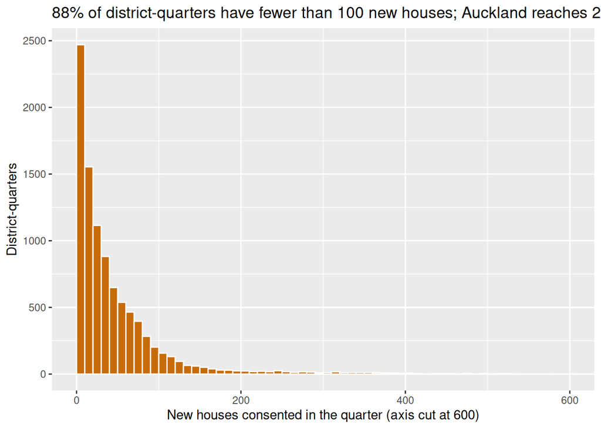

```r
ta_quarter %>%
  ggplot(aes(x = houses)) +
  geom_histogram(binwidth = 10, boundary = 0, fill = "#C76B0A", colour = "white") +
  coord_cartesian(xlim = c(0, 600)) +
  labs(title = "88% of district-quarters have fewer than 100 new houses; Auckland reaches 2,099",
       x = "New houses consented in the quarter (axis cut at 600)", y = "District-quarters")
```

```r
ta_quarter %>%
  group_by(area) %>%
  summarise(median_houses_per_quarter = median(houses), share_under_5 = mean(houses < 5)) %>%
  arrange(median_houses_per_quarter) %>%
  slice_head(n = 10) %>%
  kable(digits = 3, caption = "The ten smallest districts by median new houses per quarter")
```

The ten smallest districts by median new houses per quarter

| area | median_houses_per_quarter | share_under_5 |
| --- | --- | --- |
| Chatham Islands Territory | 0 | 0.986 |
| Kawerau District | 0 | 0.979 |
| Wairoa District | 3 | 0.800 |
| Waitomo District | 4 | 0.510 |
| Stratford District | 5 | 0.434 |
| Waimate District | 5 | 0.490 |
| Gore District | 6 | 0.352 |
| Opotiki District | 6 | 0.283 |
| Rangitikei District | 6 | 0.324 |
| Kaikoura District | 7 | 0.269 |

The sparse rows are concentrated in a few districts rather than spread evenly: Kawerau and the Chatham Islands have a median of zero new houses a quarter, Wairoa three, Waitomo four, and the ten smallest districts account for about three-quarters of all rows with fewer than five houses. A minimum-count rule therefore mostly removes most of a handful of districts, not random rows. The cleaning step has to decide between a minimum count of five, a higher threshold, or pooling small districts to years; this document only shows what each choice costs.

The response itself, restricted to rows with at least five houses:

```r
ta_quarter %>%
  filter(houses >= 5, !is.na(dollars_per_m2)) %>%
  summarise(rows = n(),
            min = min(dollars_per_m2),
            p01 = quantile(dollars_per_m2, 0.01),
            median = median(dollars_per_m2),
            p99 = quantile(dollars_per_m2, 0.99),
            max = max(dollars_per_m2)) %>%
  kable(digits = 0, format.args = list(big.mark = ","), caption = "Nominal $/m² of new houses, district-quarters with 5+ houses")
```

Nominal $/m² of new houses, district-quarters with 5+ houses

| rows | min | p01 | median | p99 | max |
| --- | --- | --- | --- | --- | --- |
| 8,662 | 225 | 551 | 1,281 | 3,810 | 5,449 |

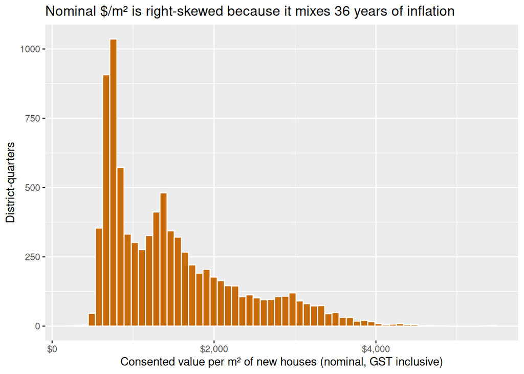

```r
ta_quarter %>%
  filter(houses >= 5) %>%
  ggplot(aes(x = dollars_per_m2)) +
  geom_histogram(bins = 60, fill = "#C76B0A", colour = "white") +
  scale_x_continuous(labels = scales::dollar) +
  labs(title = "Nominal $/m² is right-skewed because it mixes 36 years of inflation",
       x = "Consented value per m² of new houses (nominal, GST inclusive)", y = "District-quarters")
```

The median is about $1,281/m² and the 1st–99th percentile range is $551–$3,810, but the distribution is a mixture of years rather than a picture of any one market: a 1995 quarter and a 2025 quarter sit at opposite ends because of inflation alone. The extremes come from small counts even after the five-house cut:

```r
ta_quarter %>%
  filter(houses >= 5, !is.na(dollars_per_m2)) %>%
  arrange(dollars_per_m2) %>%
  dplyr::slice(c(1:3, (n() - 2):n())) %>%
  mutate(year = as.character(year)) %>%
  kable(digits = 0, format.args = list(big.mark = ","), caption = "The three lowest and three highest $/m² rows")
```

The three lowest and three highest $/m² rows

| area | year | quarter | floor_area | houses | value | dollars_per_m2 | m2_per_house |
| --- | --- | --- | --- | --- | --- | --- | --- |
| Opotiki District | 1995 | 3 | 516 | 6 | 116,043 | 225 | 86 |
| Kaikoura District | 1993 | 1 | 880 | 5 | 272,900 | 310 | 176 |
| Wairoa District | 1995 | 3 | 304 | 5 | 94,500 | 311 | 61 |
| Gisborne District | 2025 | 2 | 2,659 | 21 | 14,180,000 | 5,333 | 127 |
| Wellington City | 2025 | 1 | 5,381 | 31 | 29,167,096 | 5,420 | 174 |
| Opotiki District | 2024 | 1 | 936 | 5 | 5,100,000 | 5,449 | 187 |

Both tails belong to Ōpōtiki (spelt `Opotiki District` in this file) with five or six houses in the quarter. That is small-count noise, and it argues for either a higher threshold or a log-scale response that shrinks the tails. Whether the skew is still there once dollars are deflated is answered in the price index section.

The cross-sectional spread is the thing RQ1 is really about, so here it is for the latest complete year, 2025, for districts with at least 50 new houses in the year.

```r
spread_2025 <- ta_quarter %>%
  filter(year == 2025) %>%
  group_by(area) %>%
  summarise(houses = sum(houses), value = sum(value), floor_area = sum(floor_area), .groups = "drop") %>%
  filter(houses >= 50) %>%
  mutate(dollars_per_m2 = value / floor_area,
         m2_per_house   = floor_area / houses) %>%
  arrange(desc(dollars_per_m2))

cat("Districts with 50+ new houses in 2025:", nrow(spread_2025), "\n")
```

```
## Districts with 50+ new houses in 2025: 47
```

```r
bind_rows(slice_head(spread_2025, n = 5), slice_tail(spread_2025, n = 5)) %>%
  kable(digits = 0, format.args = list(big.mark = ","), caption = "Highest and lowest $/m² for new houses in 2025 (nominal, GST inclusive)")
```

Highest and lowest $/m² for new houses in 2025 (nominal, GST inclusive)

| area | houses | value | floor_area | dollars_per_m2 | m2_per_house |
| --- | --- | --- | --- | --- | --- |
| Queenstown-Lakes District | 592 | 535,759,193 | 118,644 | 4,516 | 200 |
| Thames-Coromandel District | 154 | 119,409,784 | 28,418 | 4,202 | 185 |
| Wellington City | 141 | 101,658,010 | 24,760 | 4,106 | 176 |
| Lower Hutt City | 112 | 61,716,380 | 16,234 | 3,802 | 145 |
| Tauranga City | 264 | 156,129,429 | 41,463 | 3,766 | 157 |
| Masterton District | 105 | 50,455,241 | 17,778 | 2,838 | 169 |
| Whanganui District | 90 | 38,970,000 | 13,976 | 2,788 | 155 |
| Ashburton District | 247 | 121,972,185 | 44,867 | 2,719 | 182 |
| Waimakariri District | 586 | 254,375,546 | 95,445 | 2,665 | 163 |
| Selwyn District | 1,413 | 665,645,936 | 256,685 | 2,593 | 182 |

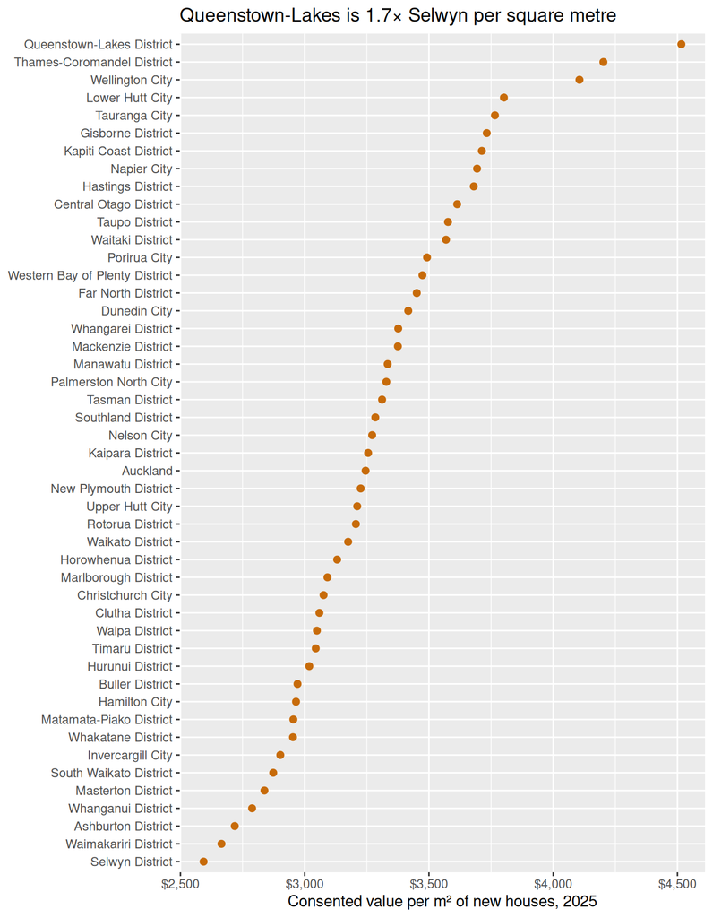

```r
spread_2025 %>%
  ggplot(aes(x = dollars_per_m2, y = fct_reorder(area, dollars_per_m2))) +
  geom_point(colour = "#C76B0A", size = 2) +
  scale_x_continuous(labels = scales::dollar) +
  labs(title = "Queenstown-Lakes is 1.7× Selwyn per square metre",
       x = "Consented value per m² of new houses, 2025", y = NULL)
```

Forty-seven districts clear the 50-house bar. Queenstown-Lakes is highest at about $4,516/m², then Thames-Coromandel, Wellington City, Lower Hutt and Tauranga; Selwyn is lowest at about $2,593, with Waimakariri, Ashburton, Whanganui and Masterton close behind. The gap between top and bottom is 1.7×, within a single year, so it cannot be inflation. Explaining that spread — tourism and lifestyle districts and the main cities at the top, the Canterbury growth plains at the bottom — is RQ1’s job. The same 2025 cross-section gives the house-size feature: a Queenstown house averages 200 m² and a Lower Hutt one 145 m², so size and cost per square metre are not simply the same thing.

How the spread developed over time, for five districts that bracket it, plus the national series:

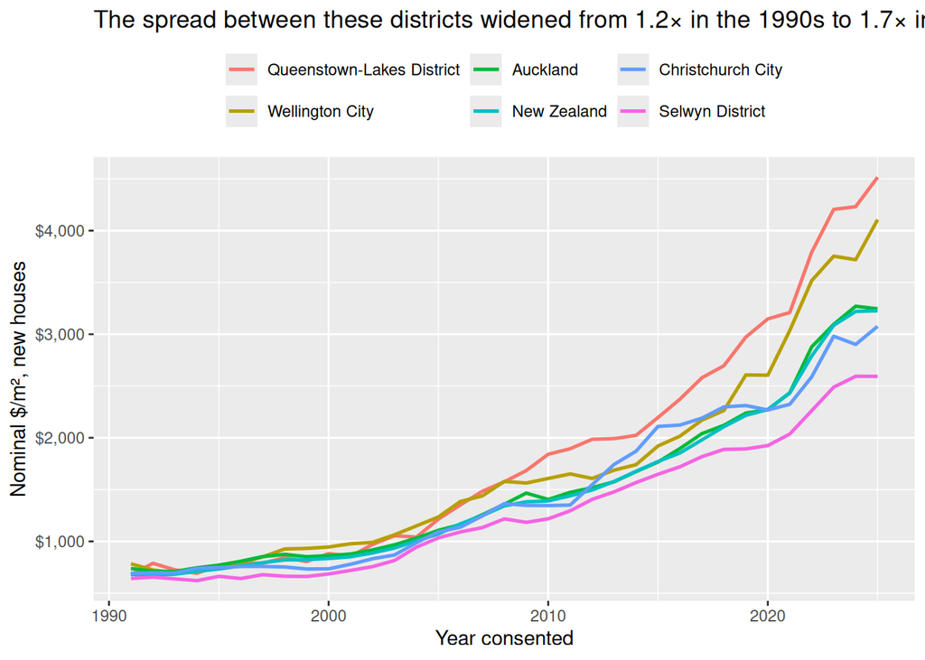

```r
named_districts <- c("Queenstown-Lakes District", "Wellington City", "Auckland",
                     "Christchurch City", "Selwyn District")

df_ta %>%
  filter(area %in% c(named_districts, "New Zealand"), work == "New", building_type == "Houses") %>%
  mutate(year = as.integer(substr(Period, 1, 4))) %>%
  filter(year >= 1991, year <= 2025) %>%
  group_by(area, year, measure) %>%
  summarise(total = sum(Data_value), .groups = "drop") %>%
  pivot_wider(names_from = measure, values_from = total) %>%
  mutate(dollars_per_m2 = Value / `Floor area`,
         area = factor(area, levels = c("Queenstown-Lakes District", "Wellington City", "Auckland",
                                        "New Zealand", "Christchurch City", "Selwyn District"))) %>%
  ggplot(aes(x = year, y = dollars_per_m2, colour = area)) +
  geom_line(linewidth = 0.9) +
  scale_y_continuous(labels = scales::dollar) +
  labs(title = "The spread between these districts widened from 1.2× in the 1990s to 1.7× in 2025",
       x = "Year consented", y = "Nominal $/m², new houses", colour = NULL) +
  theme(legend.position = "top") +
  guides(colour = guide_legend(nrow = 2))
```

In 1995 the five districts sat within about $110 of each other, between $660 and $770 per m², a ratio of 1.16 between the dearest and the cheapest. The ratio reached 1.5 in 2010 and 1.74 in 2025, when Queenstown-Lakes was at $4,516 and Selwyn at $2,593. The divergence is gradual and mostly after 2008, which suggests the year × district interaction matters and that a model with only additive district and year effects will miss part of the story. (A baseline check in the pitch work found year and district fixed effects explain about 63% of the variance in log real $/m².)

## 3.7 The rising-or-falling target for RQ3

RQ3 asks whether a district’s dwelling consents will rise or fall next year. The class is defined on calendar years of new dwelling units: a district-year is *rising* if the following year’s count is higher. Years 1991–2024 are the observation years (2025 is needed as the “next year” of 2024).

```r
ta_year_dwellings <- df_ta %>%
  filter(area %in% districts, work == "New", measure == "Number", building_type == "Dwelling units") %>%
  mutate(year = as.integer(substr(Period, 1, 4))) %>%
  filter(year >= 1991, year <= 2025) %>%
  group_by(area, year) %>%
  summarise(dwellings = sum(Data_value), .groups = "drop") %>%
  arrange(area, year) %>%
  group_by(area) %>%
  mutate(dwellings_next = lead(dwellings),
         rising = dwellings_next > dwellings) %>%
  ungroup() %>%
  filter(!is.na(dwellings_next))

ta_year_dwellings %>%
  count(rising) %>%
  mutate(share = n / sum(n)) %>%
  kable(digits = 3, caption = "District-years 1991–2024: did consents rise the following year?")
```

District-years 1991–2024: did consents rise the following year?

| rising | n | share |
| --- | --- | --- |
| FALSE | 1111 | 0.488 |
| TRUE | 1167 | 0.512 |

2,278 district-years (67 × 34), of which 51.2% were rising. The classes are balanced, which suits discriminant analysis and means accuracy is a fair headline metric. A year in which the count is unchanged counts as not rising; there are 52 such ties, and the cleaning step (`02_clean.R`, `03_features.R`) should decide whether they stay in the falling class or are dropped.

The share of districts rising in each year shows how much of the target is the national cycle:

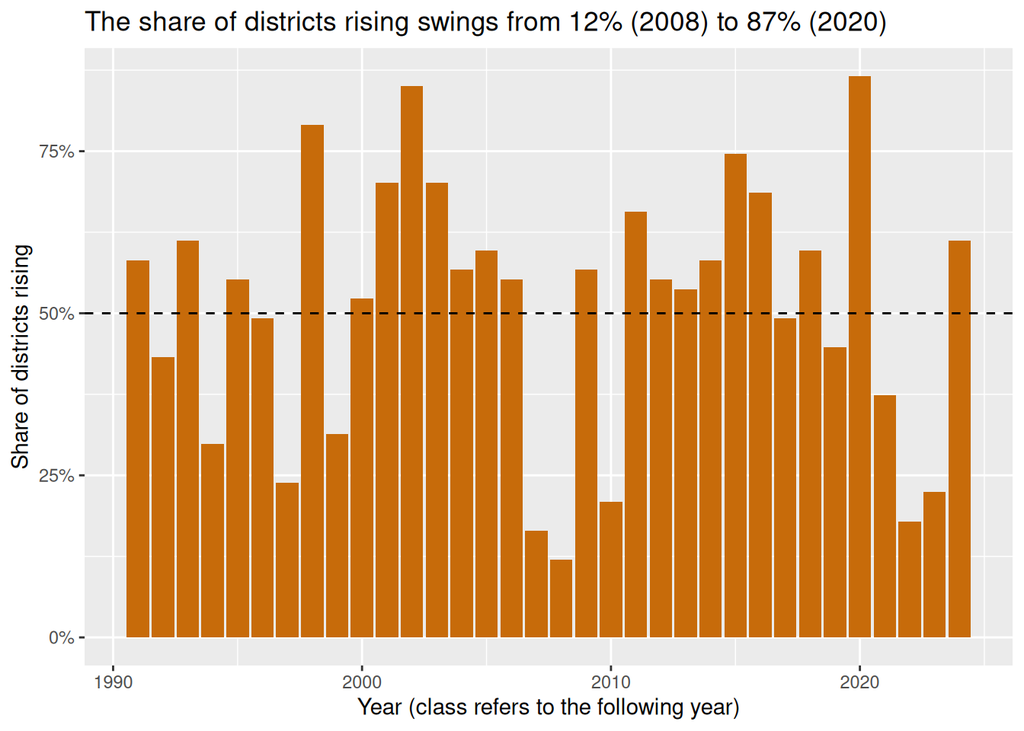

```r
ta_year_dwellings %>%
  group_by(year) %>%
  summarise(share_rising = mean(rising)) %>%
  ggplot(aes(x = year, y = share_rising)) +
  geom_col(fill = "#C76B0A") +
  geom_hline(yintercept = 0.5, linetype = "dashed") +
  scale_y_continuous(labels = scales::percent) +
  labs(title = "The share of districts rising swings from 12% (2008) to 87% (2020)",
       x = "Year (class refers to the following year)", y = "Share of districts rising")
```

The share swings from 12% of districts rising in 2008, the year the global financial crisis hit consents, to 87% in 2020. In 13 of the 34 years more than 70% of districts moved the same way; in the other 21 the picture is mixed. So the year carries real signal but does not decide the class on its own. A classifier that knows the year would still do better on a random split than it deserves, which is why RQ3 has to be validated on a time-ordered hold-out — random splitting would leak the national cycle into the test set.

## 3.8 District profiles for RQ2

RQ2 clusters districts on their building profile. One dimension of that profile, the multi-unit share, already separates districts sharply in 2025:

```r
df_ta %>%
  filter(area %in% districts, work == "New", measure == "Number",
         building_type %in% c("Houses", "Dwelling units"), substr(Period, 1, 4) == "2025") %>%
  group_by(area, building_type) %>%
  summarise(number = sum(Data_value), .groups = "drop") %>%
  pivot_wider(names_from = building_type, values_from = number) %>%
  mutate(multi_unit_share = 1 - Houses / `Dwelling units`) %>%
  filter(`Dwelling units` >= 50) %>%
  arrange(desc(multi_unit_share)) %>%
  dplyr::slice(c(1:5, (n() - 4):n())) %>%
  kable(digits = 3, format.args = list(big.mark = ","), caption = "Multi-unit share of new dwellings, 2025, districts with 50+ dwellings")
```

Multi-unit share of new dwellings, 2025, districts with 50+ dwellings

| area | Dwelling units | Houses | multi_unit_share |
| --- | --- | --- | --- |
| Lower Hutt City | 482 | 112 | 0.768 |
| Wellington City | 519 | 141 | 0.728 |
| Porirua City | 314 | 96 | 0.694 |
| Auckland | 15,617 | 5,086 | 0.674 |
| Hamilton City | 877 | 286 | 0.674 |
| Waitaki District | 83 | 76 | 0.084 |
| Westland District | 51 | 47 | 0.078 |
| Clutha District | 69 | 64 | 0.072 |
| South Waikato District | 59 | 56 | 0.051 |
| Buller District | 57 | 55 | 0.035 |

Lower Hutt (77%), Wellington City (73%) and Porirua (69%) are majority multi-unit; 13 of the 67 districts were in 2025. At the other end, rural districts are almost entirely stand-alone houses. Other profile dimensions — growth, volatility, cost per m², house size, the non-residential share — are built in the cleaning step (`02_clean.R`, `03_features.R`); this one establishes that the type mix alone already has structure worth clustering.

## 3.9 Traps in this table

- `Period` is text and must stay text (setup section).
- Floor area exists for `New` work only; `$/m²` is undefined for alterations.
- Dollars are nominal and GST inclusive; deflate before comparing years.
- 10.8% of district-quarters have fewer than five new houses; ratios there are noise.
- `Miscellaneous buildings` and the pre-1990 months exist only at national level — filter them out before pivoting, or the wide table gets a column of `NA`.
- Auckland is one TA and consented 43% of the country’s new dwellings in 2025 (section on the local board file); it will dominate any unweighted national summary and sit alone in any cluster solution.
- The building types are nested: pick one level.

The full table is no longer needed; it is removed here to keep memory for the files that follow. The derived tables above (`ta_quarter`, `ta_year_dwellings`, `ta_month_dwellings`, `ta_auckland_dwellings`, `nz_houses`, `nz_annual`) stay.

```r
rm(df_ta, hier_new)
invisible(gc())
```

# 4 Building consents by region (Monthly)

The regional file has the same layout as the TA file but a coarser geography — 16 regions, the area outside any region, the two islands, two rest-of-island groupings and the national total — and one thing the TA file lacks: **seasonally adjusted and trend series**, flagged in `Series_title_5`. It is the file to use for anything about the national or regional cycle, and the only one where `Status` is not uniformly `F`.

```r
df_region_m <- read_infoshare(f_region_m)

region_m_profile <- profile_infoshare(df_region_m)

# status by adjustment type
region_m_status <- df_region_m %>%
  count(adjustment = Series_title_5, Status) %>%
  pivot_wider(names_from = Status, values_from = n, values_fill = 0)

# the areas, with the coverage of their actual series
region_m_areas <- df_region_m %>%
  filter(Series_title_5 == "Actual") %>%
  group_by(area = Series_title_1) %>%
  summarise(first_period = min(Period), last_period = max(Period),
            series = n_distinct(Series_reference), .groups = "drop") %>%
  arrange(first_period, area)

# which series have seasonally adjusted and trend versions
region_m_adjusted <- df_region_m %>%
  filter(Series_title_5 != "Actual") %>%
  group_by(adjustment = Series_title_5, building_type = Series_title_2,
           work = Series_title_3, measure = Series_title_4) %>%
  summarise(areas = n_distinct(Series_title_1), first_period = min(Period),
            last_period = max(Period), .groups = "drop")

# national new dwellings, actual vs seasonally adjusted vs trend, kept for a plot
region_m_nz_dwellings <- df_region_m %>%
  filter(Series_title_1 == "New Zealand", Series_title_2 == "Dwelling units",
         Series_title_3 == "New", Series_title_4 == "Number", Period >= "1995.01") %>%
  dplyr::select(Period, adjustment = Series_title_5, Status, Data_value)

rm(df_region_m)
```

```r
kable(region_m_profile, caption = "Profile of the regional monthly file")
```

Profile of the regional monthly file

| item | value |
| --- | --- |
| rows | 1396468 |
| series | 3184 |
| first_period | 1965.04 |
| last_period | 2026.08 |
| periods | 737 |
| areas | 22 |
| building_types | 26 |
| work_types | 3 |
| measures | 3 |
| adjustments | 3 |
| status | F, P, R |
| suppressed | n |
| units | Dollars, Number, SQM |
| missing_values | 0 |

1,396,468 rows, as in the manifest, 22 areas, the same 26 building types as the TA file, and three adjustment types. The status flags belong entirely to the adjusted series:

```r
kable(region_m_status, caption = "Status by adjustment type")
```

Status by adjustment type

| adjustment | F | P | R |
| --- | --- | --- | --- |
| Actual | 1390768 | 0 | 0 |
| Seasonally adjusted | 0 | 4 | 1516 |
| Trend | 0 | 11 | 4169 |

Every actual value is final. The seasonally adjusted and trend values are `R` (revised) except for the latest month, which is `P` (provisional) — Stats NZ re-estimates both every month, so these series change from release to release and are the reason the project is pinned to one release. Any model that uses them should say so.

```r
kable(region_m_areas, caption = "The 22 areas and the coverage of their actual series")
```

The 22 areas and the coverage of their actual series

| area | first_period | last_period | series |
| --- | --- | --- | --- |
| New Zealand | 1965.04 | 2026.08 | 145 |
| Area outside region | 1990.04 | 2026.08 | 144 |
| Auckland Region | 1990.04 | 2026.08 | 144 |
| Bay of Plenty Region | 1990.04 | 2026.08 | 144 |
| Canterbury Region | 1990.04 | 2026.08 | 144 |
| Gisborne Region | 1990.04 | 2026.08 | 144 |
| Hawke’s Bay Region | 1990.04 | 2026.08 | 144 |
| Manawatu-Whanganui Region | 1990.04 | 2026.08 | 144 |
| Marlborough Region | 1990.04 | 2026.08 | 144 |
| Nelson Region | 1990.04 | 2026.08 | 144 |
| North Island | 1990.04 | 2026.08 | 144 |
| North Island excluding Auckland, Waikato, and Wellington regions | 1990.04 | 2026.08 | 144 |
| Northland Region | 1990.04 | 2026.08 | 144 |
| Otago Region | 1990.04 | 2026.08 | 144 |
| South Island | 1990.04 | 2026.08 | 144 |
| South Island excluding Canterbury Region | 1990.04 | 2026.08 | 144 |
| Southland Region | 1990.04 | 2026.08 | 144 |
| Taranaki Region | 1990.04 | 2026.08 | 144 |
| Tasman Region | 1990.04 | 2026.08 | 144 |
| Waikato Region | 1990.04 | 2026.08 | 144 |
| Wellington Region | 1990.04 | 2026.08 | 144 |
| West Coast Region | 1990.04 | 2026.08 | 144 |

The national total runs from April 1965; the 21 regional areas all start in April 1990, like the TAs. The groupings — North Island excluding Auckland, Waikato and Wellington; South Island excluding Canterbury — are Stats NZ’s own and exist so that the adjusted series can be published for them:

```r
kable(region_m_adjusted, caption = "Series that exist in seasonally adjusted and trend form")
```

Series that exist in seasonally adjusted and trend form

| adjustment | building_type | work | measure | areas | first_period | last_period |
| --- | --- | --- | --- | --- | --- | --- |
| Seasonally adjusted | All buildings | New plus altered | Value | 1 | 1995.01 | 2026.08 |
| Seasonally adjusted | Dwelling units | New | Number | 1 | 1995.01 | 2026.08 |
| Seasonally adjusted | Houses | New | Number | 1 | 1995.01 | 2026.08 |
| Seasonally adjusted | Residential buildings | New plus altered | Value | 1 | 1995.01 | 2026.08 |
| Trend | All buildings | New plus altered | Value | 1 | 1995.01 | 2026.08 |
| Trend | Dwelling units | New | Number | 7 | 1995.01 | 2026.08 |
| Trend | Houses | New | Number | 1 | 1995.01 | 2026.08 |
| Trend | Non-residential buildings | New plus altered | Value | 1 | 1995.01 | 2026.08 |
| Trend | Residential buildings | New plus altered | Value | 1 | 1995.01 | 2026.08 |

Seasonal adjustment is published for four national series only (all buildings, residential buildings, dwelling units and houses). The trend is published for those plus non-residential buildings nationally, and for new dwelling units in six sub-national areas as well: Auckland, Waikato, Wellington, Canterbury and the two rest-of-island groupings. All adjusted series start in January 1995. There are no regional seasonally adjusted series below that, so seasonality at TA level is ours to handle — by working in quarters or years, or with a month-of-year feature.

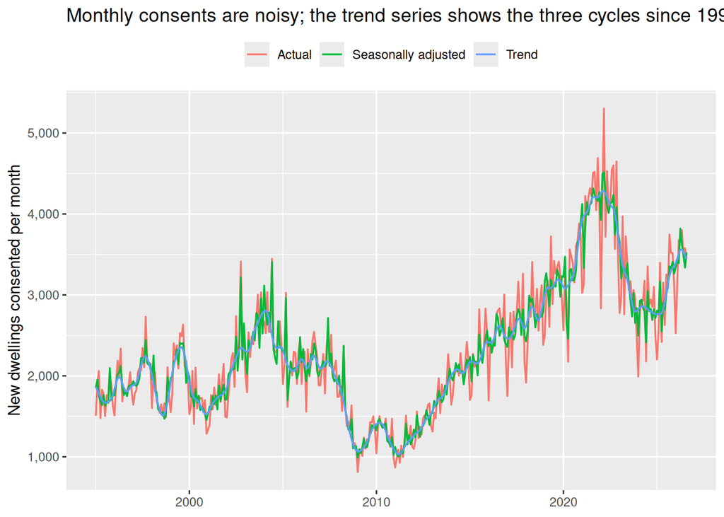

```r
region_m_nz_dwellings %>%
  mutate(month = period_to_date(Period)) %>%
  ggplot(aes(x = month, y = Data_value, colour = adjustment)) +
  geom_line(linewidth = 0.6) +
  scale_y_continuous(labels = scales::comma) +
  labs(title = "Monthly consents are noisy; the trend series shows the three cycles since 1995",
       x = NULL, y = "New dwellings consented per month", colour = NULL) +
  theme(legend.position = "top")
```

The actual series shows the within-year pattern and the month-to-month noise that makes monthly district modelling unattractive; the trend shows the early-2004 peak (about 2,800 dwellings a month), the trough of 2009–2011 after the global financial crisis (about 1,050), the long rise to the early-2022 peak (about 4,300), the fall to late 2023 and the recovery since. Those cycles are the national signal that RQ3’s rising-or-falling target has to be separated from.

# 5 Building consents by region (Quarterly)

The quarterly file is the monthly file summed to quarters by Stats NZ, with its own seasonally adjusted and trend series. The one thing to understand about it is how a quarter is written.

```r
df_region_q <- read_infoshare(f_region_q)

region_q_profile <- profile_infoshare(df_region_q)

region_q_status <- df_region_q %>%
  count(adjustment = Series_title_5, Status) %>%
  pivot_wider(names_from = Status, values_from = n, values_fill = 0)

region_q_months <- df_region_q %>%
  distinct(month_in_period = substr(Period, 6, 7)) %>%
  arrange(month_in_period)

region_q_adjusted <- df_region_q %>%
  filter(Series_title_5 != "Actual") %>%
  group_by(adjustment = Series_title_5, building_type = Series_title_2,
           work = Series_title_3, measure = Series_title_4) %>%
  summarise(areas = n_distinct(Series_title_1), first_period = min(Period),
            last_period = max(Period), quarters = n_distinct(Period), .groups = "drop")

region_q_same_areas <- setequal(unique(df_region_q$Series_title_1), region_m_areas$area)

rm(df_region_q)
```

```r
kable(region_q_profile, caption = "Profile of the regional quarterly file")
```

Profile of the regional quarterly file

| item | value |
| --- | --- |
| rows | 462736 |
| series | 3179 |
| first_period | 1965.06 |
| last_period | 2026.06 |
| periods | 245 |
| areas | 22 |
| building_types | 26 |
| work_types | 3 |
| measures | 3 |
| adjustments | 3 |
| status | F, P, R |
| suppressed | n |
| units | Dollars, Number, SQM |
| missing_values | 0 |

```r
kable(region_q_months, caption = "Months that appear in Period")
```

Months that appear in Period

| month_in_period |
| --- |
| 03 |
| 06 |
| 09 |
| 12 |

462,736 rows and the same 22 areas as the monthly file (`setequal` returns TRUE). `Period` holds only `03`, `06`, `09` and `12`: a quarter is written as its **last** month, so `1990.06` is April–June 1990, the June quarter, and the file runs from the June 1965 quarter to the June 2026 quarter. The partial September 2026 quarter is not in it, which is one reason to prefer this file over summing months ourselves when a quarterly regional series is needed.

```r
kable(region_q_status, caption = "Status by adjustment type")
```

Status by adjustment type

| adjustment | F | P | R |
| --- | --- | --- | --- |
| Actual | 461476 | 0 | 0 |
| Seasonally adjusted | 0 | 5 | 625 |
| Trend | 0 | 5 | 625 |

```r
kable(region_q_adjusted, caption = "Quarterly series with seasonally adjusted and trend versions")
```

Quarterly series with seasonally adjusted and trend versions

| adjustment | building_type | work | measure | areas | first_period | last_period | quarters |
| --- | --- | --- | --- | --- | --- | --- | --- |
| Seasonally adjusted | All buildings | New plus altered | Value | 1 | 1995.03 | 2026.06 | 126 |
| Seasonally adjusted | Dwelling units | New | Number | 1 | 1995.03 | 2026.06 | 126 |
| Seasonally adjusted | Houses | New | Number | 1 | 1995.03 | 2026.06 | 126 |
| Seasonally adjusted | Non-residential buildings | New plus altered | Value | 1 | 1995.03 | 2026.06 | 126 |
| Seasonally adjusted | Residential buildings | New plus altered | Value | 1 | 1995.03 | 2026.06 | 126 |
| Trend | All buildings | New plus altered | Value | 1 | 1995.03 | 2026.06 | 126 |
| Trend | Dwelling units | New | Number | 1 | 1995.03 | 2026.06 | 126 |
| Trend | Houses | New | Number | 1 | 1995.03 | 2026.06 | 126 |
| Trend | Non-residential buildings | New plus altered | Value | 1 | 1995.03 | 2026.06 | 126 |
| Trend | Residential buildings | New plus altered | Value | 1 | 1995.03 | 2026.06 | 126 |

The status pattern is the same as the monthly file: actuals final, adjusted series revised, the latest quarter provisional. The adjusted quarterly series start in the March 1995 quarter and cover 126 quarters.

Our own district-quarter frame is built from the monthly TA file, not from this one, because this file has no TA geography. The two must agree where they overlap: the cleaning step (`02_clean.R`, `03_features.R`) should check that summing our TA quarters to regions reproduces this file’s actual values, which also confirms the TA-to-region concordance it will need.

# 6 Building consents by Auckland local board (Monthly)

Auckland is a single territorial authority in the TA file but consents about two-fifths of the country’s new dwellings, so Stats NZ also publishes it by its 21 local boards. This file is the only sub-TA breakdown with values and floor areas (the SA2 files have counts only).

```r
df_akl <- read_infoshare(f_akl)

akl_profile <- profile_infoshare(df_akl)

akl_combos <- df_akl %>%
  count(Series_title_2, Series_title_3, Series_title_4, name = "rows") %>%
  count(rows, name = "combinations")

akl_boards <- df_akl %>%
  group_by(board = Series_title_1) %>%
  summarise(first_period = min(Period), last_period = max(Period), rows = n(), .groups = "drop")

akl_types <- sort(unique(df_akl$Series_title_2))

# do the 21 boards add up to the Auckland row of the TA file?
akl_rollup <- df_akl %>%
  filter(Series_title_2 == "Dwelling units", Series_title_3 == "New", Series_title_4 == "Number") %>%
  group_by(Period) %>%
  summarise(boards_sum = sum(Data_value), .groups = "drop") %>%
  inner_join(ta_auckland_dwellings, by = "Period") %>%
  mutate(difference = boards_sum - ta_auckland)

# new dwellings by board in 2025, for a first look
akl_2025 <- df_akl %>%
  filter(Series_title_2 == "Dwelling units", Series_title_3 == "New", Series_title_4 == "Number",
         substr(Period, 1, 4) == "2025") %>%
  group_by(board = Series_title_1) %>%
  summarise(dwellings_2025 = sum(Data_value), .groups = "drop") %>%
  arrange(desc(dwellings_2025))

rm(df_akl)
```

```r
kable(akl_profile, caption = "Profile of the Auckland local board file")
```

Profile of the Auckland local board file

| item | value |
| --- | --- |
| rows | 1321488 |
| series | 3024 |
| first_period | 1990.04 |
| last_period | 2026.08 |
| periods | 437 |
| areas | 21 |
| building_types | 25 |
| work_types | 3 |
| measures | 3 |
| adjustments | 0 |
| status | F |
| suppressed | n |
| units | Dollars, Number, SQM |
| missing_values | 0 |

```r
kable(akl_combos, caption = "Rows per building type × work × measure combination")
```

Rows per building type × work × measure combination

| rows | combinations |
| --- | --- |
| 9177 | 144 |

1,321,488 rows, 21 boards, 25 building types and 144 combinations, every one of them with exactly 9,177 rows = 21 boards × 437 months. It is the same complete grid as the TA file with one type fewer:

```r
setdiff(unique(combos$building_type), akl_types)
```

```
## [1] "Miscellaneous buildings"
```

`Miscellaneous buildings` is the one missing, as expected: it only ever existed nationally before 1990. The board file starts in April 1990 for every board, so there is nothing for it to hold.

```r
akl_rollup %>%
  summarise(months = n(), max_abs_difference = max(abs(difference)), share_exact = mean(difference == 0)) %>%
  kable(caption = "Sum of the 21 boards vs the Auckland row of the TA file, new dwelling units")
```

Sum of the 21 boards vs the Auckland row of the TA file, new dwelling units

| months | max_abs_difference | share_exact |
| --- | --- | --- |
| 437 | 0 | 1 |

The boards add up to the TA file’s Auckland row exactly in all 437 months, so the two files can be used together without reconciliation.

```r
auckland_share_2025 <- ta_month_dwellings %>%
  filter(format(month, "%Y") == "2025") %>%
  summarise(auckland = sum(`Dwelling units`[area == "Auckland"]),
            all_areas = sum(`Dwelling units`)) %>%
  mutate(share = auckland / all_areas)
kable(auckland_share_2025, digits = 3, format.args = list(big.mark = ","), caption = "Auckland's share of new dwellings consented in 2025")
```

Auckland’s share of new dwellings consented in 2025

| auckland | all_areas | share |
| --- | --- | --- |
| 15,617 | 36,619 | 0.426 |

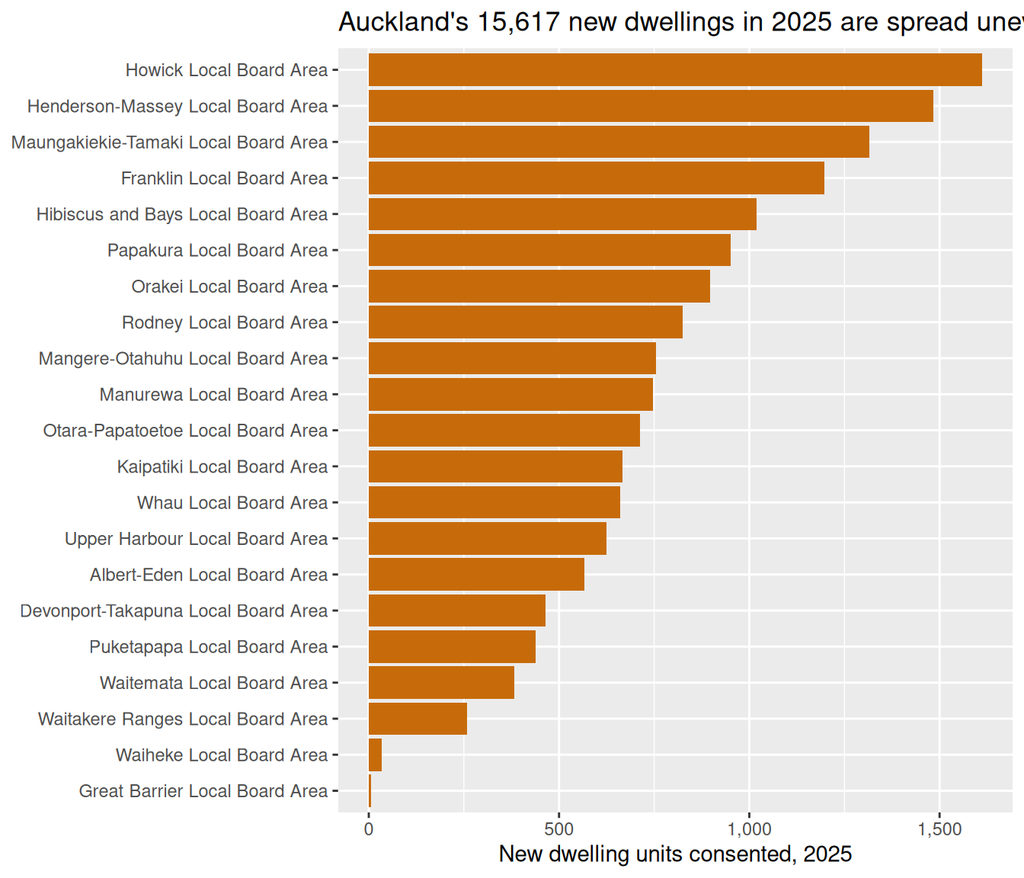

```r
akl_2025 %>%
  ggplot(aes(x = dwellings_2025, y = fct_reorder(board, dwellings_2025))) +
  geom_col(fill = "#C76B0A") +
  scale_x_continuous(labels = scales::comma) +
  labs(title = "Auckland's 15,617 new dwellings in 2025 are spread unevenly across its 21 boards",
       x = "New dwelling units consented, 2025", y = NULL)
```

Auckland consented 15,617 new dwellings in 2025, 42.6% of the national total, and the next largest district (Christchurch City, 4,084) consented about a quarter of that. Within Auckland the boards range from 1,612 in Howick to 6 on Great Barrier Island, so several boards are the size of a mid-ranking district. For RQ1 and RQ2 this is the Auckland problem: as one TA it is an outlier in volume, and any cluster solution will tend to put it on its own. The options are to keep it as one TA and accept that, to model the 21 boards as if they were districts (this file provides the values and floor areas to do so), or to work in per-capita terms. The decision belongs to the cleaning step (`02_clean.R`, `03_features.R`); this file makes the second option possible.

# 7 Building consents by institutional sector (Monthly)

The sector file splits the national totals by who applied for the consent — households, businesses, government, non-profits and the rest of the world — using the institutional sector classification from the national accounts. There is no geography in it.

```r
df_sector <- read_infoshare(f_sector)

sector_profile <- profile_infoshare(df_sector)

sector_areas <- df_sector %>%
  group_by(sector = Series_title_1) %>%
  summarise(first_period = min(Period), last_period = max(Period),
            building_types = n_distinct(Series_title_2), rows = n(), .groups = "drop") %>%
  arrange(first_period, sector)

sector_series_lengths <- df_sector %>%
  count(Series_reference, name = "periods") %>%
  count(periods, name = "series")

# who consents what: value of new work in 2025, by sector and broad building type
sector_2025 <- df_sector %>%
  filter(substr(Period, 1, 4) == "2025", Series_title_3 == "New", Series_title_4 == "Value",
         Series_title_2 %in% c("Dwelling units", "Non-residential buildings")) %>%
  group_by(building_type = Series_title_2, sector = Series_title_1) %>%
  summarise(value = sum(Data_value), .groups = "drop") %>%
  group_by(building_type) %>%
  mutate(share = value / value[sector == "Total all sectors"]) %>%
  ungroup()

rm(df_sector)
```

```r
kable(sector_profile, caption = "Profile of the institutional sector file")
```

Profile of the institutional sector file

| item | value |
| --- | --- |
| rows | 458771 |
| series | 1014 |
| first_period | 1965.04 |
| last_period | 2026.08 |
| periods | 737 |
| areas | 7 |
| building_types | 26 |
| work_types | 3 |
| measures | 3 |
| adjustments | 0 |
| status | F |
| suppressed | n |
| units | Dollars, Number, SQM |
| missing_values | 0 |

```r
kable(sector_areas, caption = "The seven sectors")
```

The seven sectors

| sector | first_period | last_period | building_types | rows |
| --- | --- | --- | --- | --- |
| Total all sectors | 1965.04 | 2026.08 | 26 | 69280 |
| Financial business enterprises | 1976.04 | 2026.08 | 26 | 65209 |
| General government institutions | 1976.04 | 2026.08 | 26 | 65341 |
| Households | 1976.04 | 2026.08 | 26 | 63752 |
| Non-financial business enterprises | 1976.04 | 2026.08 | 26 | 65341 |
| Non-profit institutions serving households | 1976.04 | 2026.08 | 26 | 65341 |
| Rest of the world | 1978.12 | 2026.08 | 25 | 64507 |

458,771 rows and the same 145 combinations as the TA file, but not a complete grid: the sector split starts in April 1976 (December 1978 for the rest of the world), and the national total in April 1965, so series lengths vary.

```r
kable(sector_series_lengths, caption = "How many periods each series covers")
```

How many periods each series covers

| periods | series |
| --- | --- |
| 168 | 5 |
| 300 | 1 |
| 437 | 900 |
| 567 | 28 |
| 569 | 32 |
| 570 | 15 |
| 573 | 9 |
| 641 | 10 |
| 643 | 2 |
| 737 | 12 |

Most series have 437 periods (from April 1990); a minority reach back into the 1970s with 567–570 periods, and the pre-1990 national rows have 641 or 737. The grid is complete from April 1990 on, which is all we use.

```r
sector_2025 %>%
  dplyr::select(-value) %>%
  pivot_wider(names_from = building_type, values_from = share) %>%
  arrange(desc(`Dwelling units`)) %>%
  kable(digits = 3, caption = "Share of the value of new work consented in 2025, by sector")
```

Share of the value of new work consented in 2025, by sector

| sector | Dwelling units | Non-residential buildings |
| --- | --- | --- |
| Total all sectors | 1.000 | 1.000 |
| Non-financial business enterprises | 0.656 | 0.621 |
| Households | 0.318 | 0.000 |
| Non-profit institutions serving households | 0.016 | 0.062 |
| Financial business enterprises | 0.006 | 0.011 |
| General government institutions | 0.004 | 0.306 |
| Rest of the world | 0.001 | 0.000 |

Households and non-financial businesses between them hold about 97% of the value of new dwellings consented in 2025 — and, perhaps surprisingly, businesses hold about two-thirds of it and households one-third, a measure of how developer-led new housing has become. Non-residential value is split between businesses (about 62%) and general government (about 31%). The file could supply a feature for RQ1 — the share of a year’s residential value consented by businesses rather than households, as a proxy for developer-led building — but only at national level, so it would vary by year alone. It is recorded here for completeness rather than for use.

# 8 Building consents by institutional control (Monthly)

The control file is the sector file’s companion: the same national totals split by who controls the applicant — private New Zealand, foreign, central government, local government.

```r
df_control <- read_infoshare(f_control)

control_profile <- profile_infoshare(df_control)

control_areas <- df_control %>%
  group_by(control = Series_title_1) %>%
  summarise(first_period = min(Period), last_period = max(Period),
            building_types = n_distinct(Series_title_2), rows = n(), .groups = "drop") %>%
  arrange(first_period, control)

control_2025 <- df_control %>%
  filter(substr(Period, 1, 4) == "2025", Series_title_3 == "New", Series_title_4 == "Value",
         Series_title_2 %in% c("Dwelling units", "Non-residential buildings")) %>%
  group_by(building_type = Series_title_2, control = Series_title_1) %>%
  summarise(value = sum(Data_value), .groups = "drop") %>%
  group_by(building_type) %>%
  mutate(share = value / value[control == "Total all controls"]) %>%
  ungroup()

rm(df_control)
```

```r
kable(control_profile, caption = "Profile of the institutional control file")
```

Profile of the institutional control file

| item | value |
| --- | --- |
| rows | 235270 |
| series | 721 |
| first_period | 1965.04 |
| last_period | 2026.08 |
| periods | 737 |
| areas | 5 |
| building_types | 26 |
| work_types | 3 |
| measures | 3 |
| adjustments | 0 |
| status | F |
| suppressed | n |
| units | Dollars, Number, SQM |
| missing_values | 0 |

```r
kable(control_areas, caption = "The five control categories")
```

The five control categories

| control | first_period | last_period | building_types | rows |
| --- | --- | --- | --- | --- |
| Total all controls | 1965.04 | 2026.08 | 26 | 69280 |
| Central government control | 1974.01 | 2026.08 | 25 | 63318 |
| Local government control | 1990.04 | 2026.08 | 25 | 62928 |
| Foreign control | 2015.03 | 2026.08 | 25 | 19872 |
| National private control | 2015.03 | 2026.08 | 25 | 19872 |

235,270 rows, five categories, final throughout. The coverage is uneven in a way that matters if anyone wants to use it: central government control starts in January 1974 and local government in April 1990, but the **private and foreign split only starts in March 2015**, so before then the file only separates government from everything else.

```r
control_2025 %>%
  dplyr::select(-value) %>%
  pivot_wider(names_from = building_type, values_from = share) %>%
  arrange(desc(`Dwelling units`)) %>%
  kable(digits = 3, caption = "Share of the value of new work consented in 2025, by control")
```

Share of the value of new work consented in 2025, by control

| control | Dwelling units | Non-residential buildings |
| --- | --- | --- |
| Total all controls | 1.000 | 1.000 |
| National private control | 0.947 | 0.604 |
| Central government control | 0.038 | 0.263 |
| Foreign control | 0.013 | 0.059 |
| Local government control | 0.003 | 0.074 |

New dwellings are almost entirely under private New Zealand control (about 95% of value in 2025, with foreign control at about 1%); government control is concentrated in non-residential building, where central and local government together hold about a third of the value. Like the sector file, this is national only and is not used in our research questions.

# 9 New dwellings consented per 1000 residents by territorial authority (Annual)

This is the supply measure: new dwelling units consented in a year, divided by the resident population, for each of the 67 territorial authorities and the country. It is the candidate alternative response for RQ1 (supply rather than cost), the obvious “market heat” feature, and the only place the release brings population in. The file is small, so it is read without caching.

```r
per1000_ta <- read_infoshare(f_per1000_ta)
kable(profile_infoshare(per1000_ta), caption = "Profile of the per-1,000-residents TA file")
```

Profile of the per-1,000-residents TA file

| item | value |
| --- | --- |
| rows | 25382 |
| series | 816 |
| first_period | 1966.03 |
| last_period | 2026.08 |
| periods | 726 |
| areas | 68 |
| building_types | 0 |
| work_types | 0 |
| measures | 0 |
| adjustments | 0 |
| status | F, P |
| suppressed | n |
| units | Number |
| missing_values | 0 |

25,382 rows and 68 areas, with `Series_title_2` to `_5` empty: the series is defined by area alone. `Status` has two values, and the 816 series are 12 per area — which needs explaining, because the file is called *annual*.

```r
per1000_ta %>%
  group_by(area = Series_title_1) %>%
  summarise(series = n_distinct(Series_reference), first_period = min(Period), last_period = max(Period), .groups = "drop") %>%
  count(series, first_period, last_period, name = "areas") %>%
  kable(caption = "Series per area and their coverage")
```

Series per area and their coverage

| series | first_period | last_period | areas |
| --- | --- | --- | --- |
| 12 | 1966.03 | 2026.08 | 1 |
| 12 | 1996.01 | 2026.08 | 67 |

```r
per1000_ta %>%
  filter(Series_title_1 == "New Zealand") %>%
  mutate(year_end_month = substr(Period, 6, 7)) %>%
  group_by(Series_reference) %>%
  summarise(year_end_months = paste(sort(unique(year_end_month)), collapse = ", "),
            first_period = min(Period), last_period = max(Period), values = n(), .groups = "drop") %>%
  kable(caption = "The 12 national series: one per year-end month")
```

The 12 national series: one per year-end month

| Series_reference | year_end_months | first_period | last_period | values |
| --- | --- | --- | --- | --- |
| BLDA.S300001 | 01 | 1967.01 | 2026.01 | 60 |
| BLDA.S300002 | 02 | 1967.02 | 2026.02 | 60 |
| BLDA.S300003 | 03 | 1966.03 | 2026.03 | 61 |
| BLDA.S300004 | 04 | 1966.04 | 2026.04 | 61 |
| BLDA.S300005 | 05 | 1966.05 | 2026.05 | 61 |
| BLDA.S300006 | 06 | 1966.06 | 2026.06 | 61 |
| BLDA.S300007 | 07 | 1966.07 | 2026.07 | 61 |
| BLDA.S300008 | 08 | 1966.08 | 2026.08 | 61 |
| BLDA.S300009 | 09 | 1966.09 | 2025.09 | 60 |
| BLDA.S300010 | 10 | 1966.10 | 2025.10 | 60 |
| BLDA.S300011 | 11 | 1966.11 | 2025.11 | 60 |
| BLDA.S300012 | 12 | 1966.12 | 2025.12 | 60 |

Each of the 12 series per area is an annual series for a different **year-end month**: `BLDA.S300001` holds years ending in January, `BLDA.S300012` years ending in December, and so on. Put together they give a rolling 12-month value at every month, so `Period = 2026.08` means the year ending August 2026. The national series starts with the year ending March 1966; the 67 TAs start with the year ending January 1996 and run to August 2026.

```r
per1000_ta %>%
  filter(Status == "P") %>%
  mutate(level = if_else(Series_title_1 == "New Zealand", "New Zealand", "Territorial authorities")) %>%
  group_by(level) %>%
  summarise(first_period = min(Period), last_period = max(Period), rows = n(), areas = n_distinct(Series_title_1), .groups = "drop") %>%
  kable(caption = "Provisional (P) values")
```

Provisional (P) values

| level | first_period | last_period | rows | areas |
| --- | --- | --- | --- | --- |
| New Zealand | 2025.01 | 2026.08 | 20 | 1 |
| Territorial authorities | 2024.01 | 2026.08 | 2144 | 67 |

The provisional flag covers the TA values for years ending January 2024 onwards (32 per district) and the national values from the year ending January 2025. Those will be revised when Stats NZ updates the population estimates underneath them. The release notes say the population figures are the 2023-base subnational estimates.

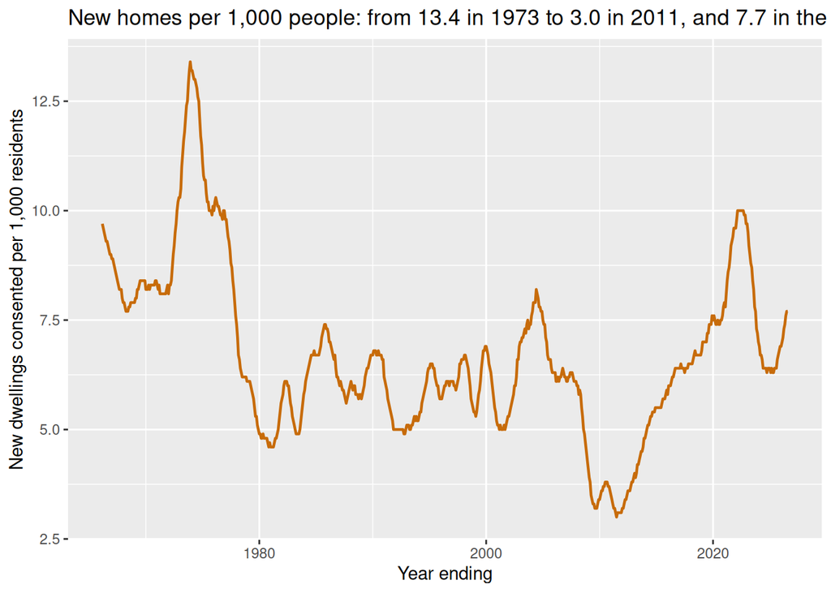

```r
per1000_ta %>%
  filter(Series_title_1 == "New Zealand") %>%
  mutate(month = period_to_date(Period)) %>%
  ggplot(aes(x = month, y = Data_value)) +
  geom_line(linewidth = 0.8, colour = "#C76B0A") +
  labs(title = "New homes per 1,000 people: from 13.4 in 1973 to 3.0 in 2011, and 7.7 in the year to August 2026",
       x = "Year ending", y = "New dwellings consented per 1,000 residents")
```

```r
per1000_latest <- per1000_ta %>%
  filter(Period == max(Period), Series_title_1 != "New Zealand") %>%
  dplyr::select(area = Series_title_1, per_1000 = Data_value, Status) %>%
  arrange(desc(per_1000))

bind_rows(slice_head(per1000_latest, n = 5), slice_tail(per1000_latest, n = 5)) %>%
  kable(caption = "New dwellings per 1,000 residents, year ending August 2026, highest and lowest districts")
```

New dwellings per 1,000 residents, year ending August 2026, highest and lowest districts

| area | per_1000 | Status |
| --- | --- | --- |
| Queenstown-Lakes District | 38.7 | P |
| Selwyn District | 27.6 | P |
| Mackenzie District | 19.2 | P |
| Central Otago District | 12.1 | P |
| Waimakariri District | 11.7 | P |
| Ruapehu District | 1.7 | P |
| Otorohanga District | 1.6 | P |
| Waitomo District | 1.1 | P |
| Kawerau District | 0.5 | P |
| Chatham Islands Territory | 0.0 | P |

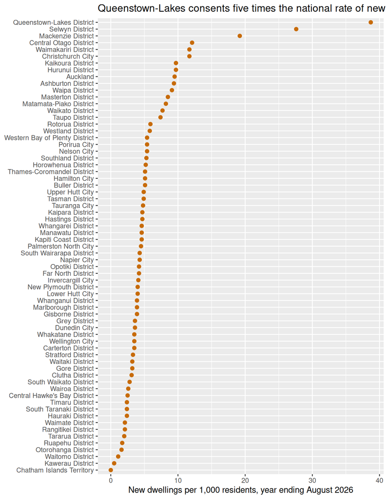

```r
per1000_latest %>%
  ggplot(aes(x = per_1000, y = fct_reorder(area, per_1000))) +
  geom_point(colour = "#C76B0A", size = 2) +
  labs(title = "Queenstown-Lakes consents five times the national rate of new homes per resident",
       x = "New dwellings per 1,000 residents, year ending August 2026", y = NULL)
```

Joining this file to a calendar-year table means taking the December series (`Period` ending `.12`) only; joining to the quarterly frame means the series ending in each quarter-end month. Using every row would give each district-year twelve nearly identical values. The TA names here match the TA file exactly, so the join key is `Series_title_1`.

# 10 New dwellings consented per 1000 residents by region (Annual)

The same measure for the 16 regions and the country, with the same 12-series-per-area structure.

```r
per1000_reg <- read_infoshare(f_per1000_reg)
kable(profile_infoshare(per1000_reg), caption = "Profile of the per-1,000-residents region file")
```

Profile of the per-1,000-residents region file

| item | value |
| --- | --- |
| rows | 6614 |
| series | 204 |
| first_period | 1966.03 |
| last_period | 2026.08 |
| periods | 726 |
| areas | 17 |
| building_types | 0 |
| work_types | 0 |
| measures | 0 |
| adjustments | 0 |
| status | F, P |
| suppressed | n |
| units | Number |
| missing_values | 0 |

```r
per1000_reg %>%
  group_by(area = Series_title_1) %>%
  summarise(series = n_distinct(Series_reference), first_period = min(Period), last_period = max(Period), .groups = "drop") %>%
  count(series, first_period, last_period, name = "areas") %>%
  kable(caption = "Series per area and their coverage")
```

Series per area and their coverage

| series | first_period | last_period | areas |
| --- | --- | --- | --- |
| 12 | 1966.03 | 2026.08 | 1 |
| 12 | 1996.01 | 2026.08 | 16 |

```r
per1000_reg %>%
  filter(Period == max(Period), Series_title_1 != "New Zealand") %>%
  dplyr::select(region = Series_title_1, per_1000 = Data_value, Status) %>%
  arrange(desc(per_1000)) %>%
  kable(caption = "New dwellings per 1,000 residents by region, year ending August 2026")
```

New dwellings per 1,000 residents by region, year ending August 2026

| region | per_1000 | Status |
| --- | --- | --- |
| Canterbury Region | 12.8 | P |
| Otago Region | 11.8 | P |
| Auckland Region | 9.5 | P |
| Waikato Region | 6.0 | P |
| Nelson Region | 5.4 | P |
| Bay of Plenty Region | 4.9 | P |
| Tasman Region | 4.9 | P |
| West Coast Region | 4.6 | P |
| Northland Region | 4.4 | P |
| Southland Region | 4.4 | P |
| Wellington Region | 4.3 | P |
| Hawke’s Bay Region | 4.2 | P |
| Manawatu-Whanganui Region | 4.0 | P |
| Gisborne Region | 3.9 | P |
| Marlborough Region | 3.9 | P |
| Taranaki Region | 3.6 | P |

6,614 rows, 17 areas, 12 series each; the national series from 1966 and the regions from 1996, with provisional values from the year ending January 2024. Canterbury (12.8), Otago (11.8) and Auckland (9.5) lead; Taranaki, Gisborne and Marlborough are under 4. Regions average over their districts, so the extremes seen at TA level (Queenstown-Lakes inside Otago, Selwyn inside Canterbury) are diluted here. Not used directly, but it is the file to cite for a regional comparison on the poster.

# 11 New dwellings consented per 1000 residents by Auckland local board (Annual)

```r
per1000_akl <- read_infoshare(f_per1000_akl)
kable(profile_infoshare(per1000_akl), caption = "Profile of the per-1,000-residents Auckland local board file")
```

Profile of the per-1,000-residents Auckland local board file

| item | value |
| --- | --- |
| rows | 7728 |
| series | 252 |
| first_period | 1996.01 |
| last_period | 2026.08 |
| periods | 368 |
| areas | 21 |
| building_types | 0 |
| work_types | 0 |
| measures | 0 |
| adjustments | 0 |
| status | F, P |
| suppressed | n |
| units | Number |
| missing_values | 0 |

```r
per1000_akl %>%
  filter(Period == max(Period)) %>%
  dplyr::select(board = Series_title_1, per_1000 = Data_value, Status) %>%
  arrange(desc(per_1000)) %>%
  kable(caption = "New dwellings per 1,000 residents by Auckland local board, year ending August 2026")
```

New dwellings per 1,000 residents by Auckland local board, year ending August 2026

| board | per_1000 | Status |
| --- | --- | --- |
| Franklin Local Board Area | 14.3 | P |
| Maungakiekie-Tamaki Local Board Area | 13.7 | P |
| Papakura Local Board Area | 13.6 | P |
| Rodney Local Board Area | 12.2 | P |
| Henderson-Massey Local Board Area | 11.3 | P |
| Albert-Eden Local Board Area | 10.8 | P |
| Orakei Local Board Area | 10.5 | P |
| Mangere-Otahuhu Local Board Area | 10.5 | P |
| Howick Local Board Area | 10.0 | P |
| Upper Harbour Local Board Area | 9.2 | P |
| Kaipatiki Local Board Area | 9.0 | P |
| Puketapapa Local Board Area | 8.9 | P |
| Manurewa Local Board Area | 8.7 | P |
| Whau Local Board Area | 8.5 | P |
| Hibiscus and Bays Local Board Area | 7.9 | P |
| Devonport-Takapuna Local Board Area | 7.9 | P |
| Otara-Papatoetoe Local Board Area | 6.9 | P |
| Waiheke Local Board Area | 4.3 | P |
| Waitakere Ranges Local Board Area | 3.0 | P |
| Great Barrier Local Board Area | 1.6 | P |
| Waitemata Local Board Area | 1.3 | P |

7,728 rows: 21 boards × 368 periods (one value per board-month, spread across the 12 year-end-month series) from the year ending January 1996, provisional from January 2024. Franklin (14.3), Maungakiekie-Tamaki (13.7) and Papakura (13.6) are building fastest per resident; Waitemata (1.3), Great Barrier (1.6) and Waitakere Ranges (3.0) slowest. If the cleaning step (`02_clean.R`, `03_features.R`) chooses to model Auckland’s boards as districts, this file supplies their per-capita rate, so the option is complete.

# 12 Non-residential outliers

A small reference file: the monthly value of very large non-residential consents, which Stats NZ removes before estimating the non-residential trend because a single hospital or stadium consent can move a month on its own. There is no geography.

```r
outliers <- read_infoshare(f_outliers)
kable(profile_infoshare(outliers), caption = "Profile of the non-residential outliers file")
```

Profile of the non-residential outliers file

| item | value |
| --- | --- |
| rows | 912 |
| series | 3 |
| first_period | 1990.01 |
| last_period | 2026.08 |
| periods | 440 |
| areas | 2 |
| building_types | 1 |
| work_types | 0 |
| measures | 0 |
| adjustments | 0 |
| status | F |
| suppressed | n |
| units | Dollars, value |
| missing_values | 0 |

```r
outliers %>%
  group_by(Series_reference, Group, Series_title_1, Series_title_2, Units) %>%
  summarise(first_period = min(Period), last_period = max(Period), months = n(),
            months_with_a_consent = sum(Data_value > 0),
            largest_month_millions = max(Data_value) / 1e6, .groups = "drop") %>%
  kable(digits = 0, caption = "The three series")
```

The three series

| Series_reference | Group | Series_title_1 | Series_title_2 | Units | first_period | last_period | months | months_with_a_consent | largest_month_millions |
| --- | --- | --- | --- | --- | --- | --- | --- | --- | --- |
| BLDM.SLE2 | Non-residential buildings $25m and over (Disc October 2017) | Large non-residential | Value | value | 1990.01 | 2017.08 | 332 | 120 | 340 |
| BLDM.SPE2 | Non-residential buildings $50 million and over (Disc October 2017) | Large non-residential | Value | value | 1990.01 | 2017.08 | 332 | 38 | 282 |
| BLDM.SXC | Non-residential building outliers | $100 million and above | NA | Dollars | 2006.01 | 2026.08 | 248 | 30 | 352 |

Three series. Two — consents of $25 million and over, and $50 million and over — were discontinued in October 2017 and have `Units = value` in lower case, a labelling inconsistency to be aware of. The current series, `BLDM.SXC`, is consents of **$100 million and above** from January 2006; it is non-zero in 30 of its 248 months, the largest being about $352 million in September 2025.

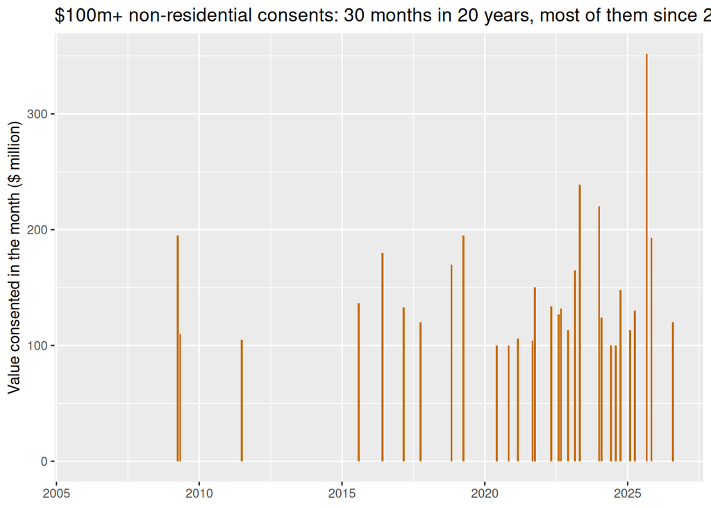

```r
outliers %>%
  filter(Series_reference == "BLDM.SXC") %>%
  mutate(month = period_to_date(Period)) %>%
  ggplot(aes(x = month, y = Data_value / 1e6)) +
  geom_col(fill = "#C76B0A") +
  labs(title = "$100m+ non-residential consents: 30 months in 20 years, most of them since 2015",
       x = NULL, y = "Value consented in the month ($ million)")
```

The relevance to us is indirect. These consents sit inside the non-residential value in the TA file, where a single one can double a district’s non-residential total for the quarter. If non-residential activity becomes a feature in RQ1, this file says which months to inspect for such spikes, though not which district they fell in.

# 13 NZ percentage change (Monthly)

The last file in the main zip holds three derived series: the percentage change in national new dwelling consents from the same month a year earlier (actual), and the month-on-month percentage change in the seasonally adjusted dwelling and house series.

```r
pctchange <- read_infoshare(f_pctchange)
kable(profile_infoshare(pctchange), caption = "Profile of the NZ percentage change file")
```

Profile of the NZ percentage change file

| item | value |
| --- | --- |
| rows | 1483 |
| series | 3 |
| first_period | 1966.04 |
| last_period | 2026.08 |
| periods | 725 |
| areas | 2 |
| building_types | 2 |
| work_types | 2 |
| measures | 0 |
| adjustments | 0 |
| status | F, R |
| suppressed | n |
| units | Percent |
| missing_values | 0 |

```r
pctchange %>%
  group_by(Series_reference, Series_title_1, Series_title_2, Series_title_3, Status) %>%
  summarise(first_period = min(Period), last_period = max(Period), months = n(),
            min_pct = min(Data_value), max_pct = max(Data_value), .groups = "drop") %>%
  kable(digits = 1, caption = "The three series")
```

The three series

| Series_reference | Series_title_1 | Series_title_2 | Series_title_3 | Status | first_period | last_period | months | min_pct | max_pct |
| --- | --- | --- | --- | --- | --- | --- | --- | --- | --- |
| BLDM.STTZ1100A1AAC | New Zealand Dwelling Units New Number | Actual | Percentage change from same period previous year | F | 1966.04 | 2026.08 | 725 | -57.5 | 83.8 |
| BLDM.STTZ1100A1SPC | New Zealand Dwelling Units New Number | Seasonally adjusted | Percentage change from previous period | R | 1995.02 | 2026.08 | 379 | -42.6 | 36.3 |
| BLDM.STTZ1110A1SPC | New Zealand Houses Units New Number | Seasonally adjusted | Percentage change from previous period | R | 1995.02 | 2026.08 | 379 | -23.0 | 28.1 |

1,483 rows. The year-on-year series runs from April 1966 and is final; the two seasonally adjusted series run from February 1995 and are `R` throughout, because the seasonal adjustment they derive from is re-estimated monthly. The year-on-year change ranges from −58% to +84%, which is the scale of swing in monthly national consents.

Everything here can be recomputed from the regional file, so the file is a convenience rather than a source. Its only use for us is as a check: the cleaning step (`02_clean.R`, `03_features.R`) can confirm that the year-on-year change it computes from the TA file’s national row matches `BLDM.STTZ1100A1AAC`.

# 14 New dwellings consented by 2026 statistical area 2 (Monthly)

The second zip holds the finest geography in the release: monthly counts of new dwellings for 2,396 statistical areas (SA2s — neighbourhoods of a few thousand people), by dwelling type, from April 1990. It is a different shape from everything above — a tidy wide table with one row per SA2 per month — and it holds **counts only**: no value, no floor area. It is the basis of the optional RQ4 (where will new homes be built) and the finest level at which RQ2’s district profiles could be built.

```r
sa2_cols <- cols(
  month                        = col_date(),
  SA2_code                     = col_character(),   # an identifier, kept as text
  SA2_name                     = col_character(),
  territorial_authority        = col_character(),
  total_dwelling_units         = col_integer(),
  houses                       = col_integer(),
  apartments                   = col_integer(),
  retirement_village_units     = col_integer(),
  townhouses_flats_units_other = col_integer()
)

df_sa2 <- read_csv(data_file(f_sa2_2026), col_types = sa2_cols, progress = FALSE)
```

```r
tibble(rows           = nrow(df_sa2),
       sa2s           = n_distinct(df_sa2$SA2_code),
       tas            = n_distinct(df_sa2$territorial_authority),
       first_month    = min(df_sa2$month),
       last_month     = max(df_sa2$month),
       months         = n_distinct(df_sa2$month),
       rows_per_sa2   = paste(unique(count(df_sa2, SA2_code)$n), collapse = ", "),
       missing_values = sum(is.na(df_sa2))) %>%
  mutate(across(everything(), as.character)) %>%
  pivot_longer(everything(), names_to = "item", values_to = "value") %>%
  kable(caption = "Profile of the 2026 SA2 file")
```

Profile of the 2026 SA2 file

| item | value |
| --- | --- |
| rows | 1047052 |
| sa2s | 2396 |
| tas | 68 |
| first_month | 1990-04-01 |
| last_month | 2026-08-01 |
| months | 437 |
| rows_per_sa2 | 437 |
| missing_values | 0 |

1,047,052 rows = 2,396 SA2s × 437 months, every SA2 present in every month, no missing values. `month` is a proper date (`YYYY-MM-01`) rather than the `YYYY.MM` text of the Infoshare files. A random sample of rows shows the layout:

```r
df_sa2 %>%
  slice_sample(n = 6) %>%
  arrange(month) %>%
  kable(caption = "Six random SA2-months")
```

Six random SA2-months

| month | SA2_code | SA2_name | territorial_authority | total_dwelling_units | houses | apartments | retirement_village_units | townhouses_flats_units_other |
| --- | --- | --- | --- | --- | --- | --- | --- | --- |
| 1990-07-01 | 112102 | Ara Hill | Auckland | 0 | 0 | 0 | 0 | 0 |
| 1994-06-01 | 133000 | Devonport | Auckland | 0 | 0 | 0 | 0 | 0 |
| 1998-04-01 | 253101 | Hataitai North West | Wellington City | 0 | 0 | 0 | 0 | 0 |
| 1998-07-01 | 150400 | Howick West | Auckland | 1 | 1 | 0 | 0 | 0 |
| 2016-07-01 | 143800 | Greenlane South | Auckland | 0 | 0 | 0 | 0 | 0 |
| 2017-07-01 | 186400 | Matarawa | South Waikato District | 0 | 0 | 0 | 0 | 0 |

## 14.1 Zero inflation

The first thing to know about this table is how many of its rows are zero.

```r
df_sa2 %>%
  summarise(sa2_months = n(),
            share_zero = mean(total_dwelling_units == 0),
            share_parts_equal_total = mean(houses + apartments + retirement_village_units +
                                             townhouses_flats_units_other == total_dwelling_units),
            max_in_one_sa2_month = max(total_dwelling_units),
            total_dwellings = sum(total_dwelling_units)) %>%
  mutate(across(everything(), as.character)) %>%
  pivot_longer(everything(), names_to = "item", values_to = "value") %>%
  kable()
```

| item | value |
| --- | --- |
| sa2_months | 1047052 |
| share_zero | 0.670887405783094 |
| share_parts_equal_total | 1 |
| max_in_one_sa2_month | 417 |
| total_dwellings | 973538 |

```r
df_sa2 %>%
  mutate(bucket = cut(total_dwelling_units,
                      breaks = c(-1, 0, 1, 2, 5, 10, 20, 50, Inf),
                      labels = c("0", "1", "2", "3–5", "6–10", "11–20", "21–50", "51+"))) %>%
  count(bucket, name = "sa2_months") %>%
  mutate(share = sa2_months / sum(sa2_months)) %>%
  kable(digits = 4, format.args = list(big.mark = ","), caption = "New dwellings per SA2-month")
```

New dwellings per SA2-month

| bucket | sa2_months | share |
| --- | --- | --- |
| 0 | 702,454 | 0.6709 |
| 1 | 181,297 | 0.1731 |
| 2 | 70,486 | 0.0673 |
| 3–5 | 59,985 | 0.0573 |
| 6–10 | 20,450 | 0.0195 |
| 11–20 | 8,349 | 0.0080 |
| 21–50 | 3,304 | 0.0032 |
| 51+ | 727 | 0.0007 |

Two-thirds (67.1%) of SA2-months have no new dwelling at all, another 17% have exactly one, and fewer than 1% have more than 20. The four dwelling-type columns sum to the total in every row, so the total is redundant and the parts are reliable. The largest single value is 417 dwellings in one SA2 in one month:

```r
df_sa2 %>%
  slice_max(total_dwelling_units, n = 3, with_ties = FALSE) %>%
  kable(caption = "The three largest SA2-months")
```

The three largest SA2-months

| month | SA2_code | SA2_name | territorial_authority | total_dwelling_units | houses | apartments | retirement_village_units | townhouses_flats_units_other |
| --- | --- | --- | --- | --- | --- | --- | --- | --- |
| 2004-12-01 | 135300 | Symonds Street West | Auckland | 417 | 0 | 417 | 0 | 0 |
| 2004-04-01 | 134500 | Anzac Avenue | Auckland | 389 | 0 | 389 | 0 | 0 |
| 2003-11-01 | 133400 | Hobson Ridge Central | Auckland | 375 | 0 | 375 | 0 | 0 |

All three are central Auckland SA2s in 2003–2004, the peak of the inner-city apartment boom — a single consent for a tower counts every unit in it. That is the multi-unit lumpiness the release notes warn about, at its most extreme.

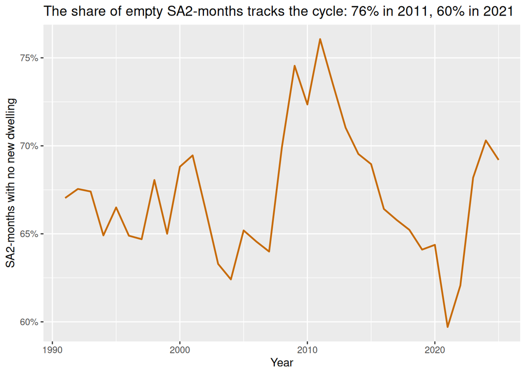

```r
df_sa2 %>%
  mutate(year = as.integer(format(month, "%Y"))) %>%
  filter(year >= 1991, year <= 2025) %>%
  group_by(year) %>%
  summarise(share_zero = mean(total_dwelling_units == 0), .groups = "drop") %>%
  ggplot(aes(x = year, y = share_zero)) +
  geom_line(linewidth = 0.8, colour = "#C76B0A") +
  scale_y_continuous(labels = scales::percent) +
  labs(title = "The share of empty SA2-months tracks the cycle: 76% in 2011, 60% in 2021",
       x = "Year", y = "SA2-months with no new dwelling")
```

```r
df_sa2 %>%
  group_by(SA2_code, SA2_name, territorial_authority) %>%
  summarise(dwellings_1990_2026 = sum(total_dwelling_units), .groups = "drop") %>%
  summarise(sa2s = n(),
            never_consented_a_dwelling = sum(dwellings_1990_2026 == 0),
            share_never = mean(dwellings_1990_2026 == 0),
            median_over_36_years = median(dwellings_1990_2026),
            max_over_36_years = max(dwellings_1990_2026)) %>%
  kable(digits = 3, caption = "Dwellings per SA2 over the whole period")
```

Dwellings per SA2 over the whole period

| sa2s | never_consented_a_dwelling | share_never | median_over_36_years | max_over_36_years |
| --- | --- | --- | --- | --- |
| 2396 | 90 | 0.038 | 301.5 | 3924 |

About 4% of SA2s never consented a dwelling in 36 years — oceanic, inlet and industrial areas that exist in the classification but hold no housing. They can be dropped from any SA2-level model without loss.

## 14.2 How SA2s sit inside districts

```r
df_sa2 %>%
  distinct(territorial_authority, SA2_code) %>%
  count(territorial_authority, name = "sa2s") %>%
  arrange(desc(sa2s)) %>%
  dplyr::slice(c(1:5, (n() - 4):n())) %>%
  kable(caption = "SA2s per territorial authority: the five largest and five smallest")
```

SA2s per territorial authority: the five largest and five smallest

| territorial_authority | sa2s |
| --- | --- |
| Auckland | 633 |
| Christchurch City | 179 |
| Wellington City | 86 |
| Dunedin City | 68 |
| Hamilton City | 68 |
| Wairoa District | 6 |
| Carterton District | 5 |
| Kawerau District | 4 |
| Chatham Islands Territory | 2 |
| Kaikoura District | 2 |

Auckland has 633 SA2s, Christchurch 179, Wellington 86; the Chatham Islands and Kaikoura have two each. If RQ2 clustered SA2s instead of districts, Auckland would be a quarter of the sample on its own.

Because the file names the parent TA, it should roll up to the TA file. It does — but only after a spelling difference is fixed:

```r
sa2_rollup <- df_sa2 %>%
  group_by(territorial_authority, month) %>%
  summarise(across(c(total_dwelling_units, houses, apartments,
                     retirement_village_units, townhouses_flats_units_other), sum),
            .groups = "drop")

# TA names in the SA2 file that do not appear in the TA file
sa2_rollup %>%
  distinct(territorial_authority) %>%
  anti_join(distinct(ta_month_dwellings, area), by = c("territorial_authority" = "area")) %>%
  kable(caption = "SA2-file TA names with no match in the TA file")
```

SA2-file TA names with no match in the TA file

| territorial_authority |
| --- |
| Ōpōtiki District |
| Ōtorohanga District |

The SA2 file writes Ōpōtiki and Ōtorohanga with macrons; the Infoshare files write them without. A join on the name silently drops both districts. Stripping diacritics from the SA2 names fixes it, and is safer than a two-name recode because any future release could add macrons elsewhere.

```r
sa2_rollup <- sa2_rollup %>%
  mutate(area = stringi::stri_trans_general(territorial_authority, "Latin-ASCII"))

sa2_rollup %>%
  inner_join(ta_month_dwellings, by = c("area", "month")) %>%
  summarise(ta_months = n(),
            diff_dwelling_units = max(abs(total_dwelling_units - `Dwelling units`)),
            diff_houses = max(abs(houses - Houses)),
            diff_apartments = max(abs(apartments - Apartments)),
            diff_retirement_village_units = max(abs(retirement_village_units - `Retirement village units`)),
            diff_townhouses_flats_units_other =
              max(abs(townhouses_flats_units_other - `Townhouses, flats, units, and other dwellings`))) %>%
  pivot_longer(-ta_months, names_to = "dwelling_type", names_prefix = "diff_", values_to = "max_abs_difference") %>%
  kable(caption = "SA2 file summed to TA × month vs the TA file, new dwellings")
```

SA2 file summed to TA × month vs the TA file, new dwellings

| ta_months | dwelling_type | max_abs_difference |
| --- | --- | --- |
| 29716 | dwelling_units | 0 |
| 29716 | houses | 0 |
| 29716 | apartments | 0 |
| 29716 | retirement_village_units | 0 |
| 29716 | townhouses_flats_units_other | 0 |

All 29,716 TA-months match exactly for every dwelling type: the SA2 counts are the TA counts, disaggregated. That means the two files can be mixed freely — SA2 counts for geography, TA values and floor areas for cost — and that the SA2 file can supply a within-district concentration feature for RQ1 (how much of a district’s building happens in its busiest few SA2s) without any reconciliation.

`SA2_code` is kept as character. The codes are six digits and happen to have no leading zeros, but they are identifiers, and treating them as numbers invites accidental arithmetic. The same applies to the TA codes embedded in `Series_reference`.

# 15 New dwellings consented by 2023 statistical area 2 (Monthly)

The same table on the 2023 SA2 boundaries. Stats NZ publishes both so that users can join to the 2023 Census (2023 boundaries) or to current geographies (2026). We need to know how different they are.

```r
df_sa2_2023 <- read_csv(data_file(f_sa2_2023), col_types = sa2_cols, progress = FALSE)

sa2_2023_summary <- tibble(rows = nrow(df_sa2_2023),
                           sa2s = n_distinct(df_sa2_2023$SA2_code),
                           tas = n_distinct(df_sa2_2023$territorial_authority),
                           first_month = min(df_sa2_2023$month),
                           last_month = max(df_sa2_2023$month),
                           total_dwellings = sum(df_sa2_2023$total_dwelling_units)) %>%
  mutate(across(everything(), as.character)) %>%
  pivot_longer(everything(), names_to = "item", values_to = "value")

codes_2026 <- distinct(df_sa2, SA2_code, SA2_name, territorial_authority)
codes_2023 <- distinct(df_sa2_2023, SA2_code, SA2_name, territorial_authority)
sa2_only_2026 <- anti_join(codes_2026, codes_2023, by = "SA2_code")
sa2_only_2023 <- anti_join(codes_2023, codes_2026, by = "SA2_code")
sa2_renamed <- inner_join(codes_2023, codes_2026, by = "SA2_code", suffix = c("_2023", "_2026")) %>%
  filter(SA2_name_2023 != SA2_name_2026)

# do the two versions give the same district totals?
sa2_version_check <- df_sa2_2023 %>%
  group_by(territorial_authority, month) %>%
  summarise(total_2023 = sum(total_dwelling_units), .groups = "drop") %>%
  inner_join(df_sa2 %>%
               group_by(territorial_authority, month) %>%
               summarise(total_2026 = sum(total_dwelling_units), .groups = "drop"),
             by = c("territorial_authority", "month")) %>%
  mutate(difference = total_2026 - total_2023)

rm(df_sa2_2023)
```

```r
kable(sa2_2023_summary, caption = "Profile of the 2023 SA2 file")
```

Profile of the 2023 SA2 file

| item | value |
| --- | --- |
| rows | 1046615 |
| sa2s | 2395 |
| tas | 68 |
| first_month | 1990-04-01 |
| last_month | 2026-08-01 |
| total_dwellings | 973538 |

```r
kable(sa2_only_2026, caption = "SA2 codes only in the 2026 file")
```

SA2 codes only in the 2026 file

| SA2_code | SA2_name | territorial_authority |
| --- | --- | --- |
| 363701 | Oceanic Southland Region | Area Outside Territorial Authority |
| 363702 | Inlets Stewart Island/Rakiura | Southland District |

```r
kable(sa2_only_2023, caption = "SA2 codes only in the 2023 file")
```

SA2 codes only in the 2023 file

| SA2_code | SA2_name | territorial_authority |
| --- | --- | --- |
| 363700 | Oceanic Southland Region | Area Outside Territorial Authority |

```r
cat("SA2 codes present in both files but with different names:", nrow(sa2_renamed), "\n")
```

```
## SA2 codes present in both files but with different names: 0
```

The two files differ by one boundary change: in the 2023 geography SA2 `363700` (Oceanic Southland Region) covers the waters off Southland; in 2026 it is split into `363701` (the same name, still outside any TA) and `363702` (Inlets Stewart Island/Rakiura, assigned to Southland District). Every other code and name is identical, and both files hold 973,538 dwellings in total.

```r
sa2_version_check %>%
  summarise(ta_months = n(),
            share_identical = mean(difference == 0),
            max_abs_difference = max(abs(difference))) %>%
  kable(digits = 4, caption = "District × month totals, 2026 boundaries vs 2023 boundaries")
```

District × month totals, 2026 boundaries vs 2023 boundaries

| ta_months | share_identical | max_abs_difference |
| --- | --- | --- |
| 29716 | 0.9998 | 1 |

```r
sa2_version_check %>%
  filter(difference != 0) %>%
  kable(caption = "The TA-months that differ")
```

The TA-months that differ

| territorial_authority | month | total_2023 | total_2026 | difference |
| --- | --- | --- | --- | --- |
| Kawerau District | 1994-12-01 | 0 | 1 | 1 |
| Kawerau District | 1997-06-01 | 0 | 1 | 1 |
| Kawerau District | 2021-09-01 | 1 | 2 | 1 |
| Whakatane District | 1994-12-01 | 11 | 10 | -1 |
| Whakatane District | 1997-06-01 | 16 | 15 | -1 |
| Whakatane District | 2021-09-01 | 14 | 13 | -1 |

District totals are identical in all but six TA-months, where a single dwelling moves between Kawerau and Whakatāne — a small boundary adjustment between the two versions. For our purposes the files are interchangeable at district level; we use the **2026** file unless a join to 2023 Census data is needed, and `R/scripts/03_features.R` uses it.

# 16 The release tables workbook

The third download is not data for modelling but documentation: the Excel workbook of published tables (tables 1–9) with the footnotes that define the series. It is optional: if `building-consents-issued-august-2026.xlsx` is anywhere under the data folder, its sheet names are listed.

```r
xlsx_path <- .all_data_files[basename(.all_data_files) == "building-consents-issued-august-2026.xlsx"][1]

if (!is.na(xlsx_path) && requireNamespace("readxl", quietly = TRUE)) {
  readxl::excel_sheets(xlsx_path)
} else {
  cat("Workbook not found under the data folder (optional; definitions are summarised below)\n")
}
```

```
## Workbook not found under the data folder (optional; definitions are summarised below)
```

The footnotes are the source for the definitions used throughout this document and the pitch:

- values are **GST inclusive and not inflation adjusted**;
- consents valued **under $5,000 are excluded**, as are consents mainly for demolition;
- for **staged consents**, the value is recorded at each stage but floor area and dwelling counts at the largest stage, so value ÷ floor area can spike in individual months;
- **floor areas are imputed** when a consent does not state one;
- each dwelling in a multi-unit project is **counted separately**;
- seasonally adjusted and trend series are **revised every month**; the non-residential trend excludes consents of $100 million and over (the outliers file above);
- the per-1,000-residents series use the **2023-base subnational population estimates**.

# 17 The price index for deflating dollars

Every dollar value in the release is nominal, and the national $/m² series rose 4.7× between 1991 and 2025 largely because of inflation. To compare costs across years the values have to be deflated, and the right deflator for consented building work is Stats NZ’s Capital Goods Price Index for residential buildings (series `CEPQ.S61101`, quarterly, base September 2022 = 1000), from the *Business price indexes* release. It is a separate download (`business-price-indexes-june-2026-csv.csv`), found through `config.R` like the other files.

```r
cgpi_files <- data_file(f_prices)
cgpi_ok <- length(cgpi_files) == 1 &&
  all(c("Series_reference", "Period", "Data_value") %in%
        names(read_csv(cgpi_files[1], n_max = 0, col_types = cols(.default = col_character()), progress = FALSE)))
cat("Price index file found:", cgpi_ok, "\n")
```

```
## Price index file found: TRUE
```

```r
if (length(cgpi_files) > 0) print(basename(cgpi_files))
```

```
## [1] "business-price-indexes-june-2026-csv.csv"
```

```r
cgpi <- read_csv(cgpi_files[1], col_types = cols(.default = col_character()), progress = FALSE) %>%
  filter(Series_reference == "CEPQ.S61101") %>%
  transmute(Period, index = as.numeric(Data_value), Status = STATUS)

cat("Quarters:", nrow(cgpi), " from", min(cgpi$Period), "to", max(cgpi$Period), "\n")
```

```
## Quarters: 147  from 1989.12 to 2026.06
```

```r
# annual average of the quarterly index, and the latest quarter as the base
cgpi_annual <- cgpi %>%
  mutate(year = as.integer(substr(Period, 1, 4))) %>%
  group_by(year) %>%
  summarise(index = mean(index), quarters = n(), .groups = "drop") %>%
  filter(quarters == 4)

base_index <- cgpi %>% filter(Period == max(Period)) %>% pull(index)

nz_houses_real <- nz_houses %>%
  inner_join(cgpi_annual, by = "year") %>%
  mutate(real_dollars_per_m2 = dollars_per_m2 * base_index / index)

nz_houses_real %>%
  filter(year %in% c(1991, 2005, 2010, 2023, 2025)) %>%
  dplyr::select(year, houses, dollars_per_m2, index, real_dollars_per_m2) %>%
  mutate(year = as.character(year)) %>%
  kable(digits = 0, format.args = list(big.mark = ","),
        caption = paste0("New houses: nominal vs real $/m² (in dollars of ", max(cgpi$Period), ")"))
```

New houses: nominal vs real $/m² (in dollars of 2026.06)

| year | houses | dollars_per_m2 | index | real_dollars_per_m2 |
| --- | --- | --- | --- | --- |
| 1991 | 12,380 | 681 | 263 | 2,915 |
| 2005 | 19,390 | 1,071 | 461 | 2,622 |
| 2010 | 13,066 | 1,391 | 535 | 2,932 |
| 2023 | 15,675 | 3,086 | 1,050 | 3,312 |
| 2025 | 16,635 | 3,226 | 1,099 | 3,309 |

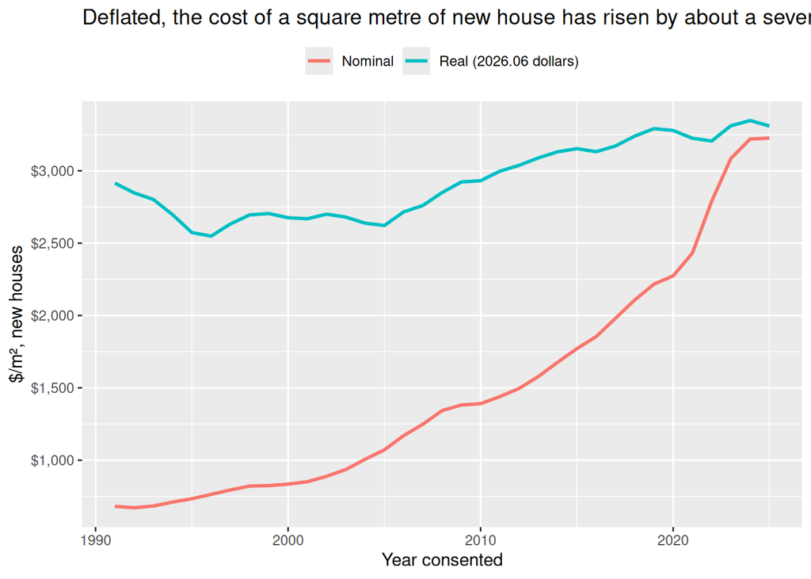

```r
nz_houses_real %>%
  dplyr::select(year, dollars_per_m2, real_dollars_per_m2) %>%   # drop `value` first: it would clash with values_to
  pivot_longer(-year, names_to = "basis", values_to = "y") %>%
  mutate(basis = if_else(basis == "dollars_per_m2", "Nominal", paste0("Real (", max(cgpi$Period), " dollars)"))) %>%
  ggplot(aes(x = year, y = y, colour = basis)) +
  geom_line(linewidth = 1) +
  scale_y_continuous(labels = scales::dollar) +
  labs(title = "Deflated, the cost of a square metre of new house has risen by about a seventh since 1991",
       x = "Year consented", y = "$/m², new houses", colour = NULL) +
  theme(legend.position = "top")
```

In the pitch profiling (done in Python on the same release) the real series went from about $2,900/m² in 1991 to about $3,300 in 2025 in June-2026 dollars, an increase of roughly 14% against the nominal 4.7×. The chunks above reproduce that in R once the index file is in place; the exact figures depend on whether the quarterly index is averaged to years (as here) or applied quarter by quarter, which `R/scripts/03_features.R` fixes: it applies the index quarter by quarter.

Decision recorded for RQ1: the response is **real** $/m², deflated by `CEPQ.S61101` to the latest quarter’s dollars. The index is quarterly and uses the quarter-end month in `Period` (`2026.06` = June 2026 quarter), so it joins to the district-quarter frame directly. The index file is downloaded separately from the consents release and must be pinned too — the June 2026 quarter release.

# 18 What this means for the cleaning pipeline

The decisions this analysis settles, or leaves to `R/scripts/02_clean.R` and `03_features.R`, in the order the pipeline will meet them:

1. **Read `Period` as text** in every Infoshare file, converting with `period_to_date()` where a date is needed. Quarterly files write a quarter as its last month.
2. **One release, one deflator.** The consents release is pinned to August 2026 and the price index to the June 2026 quarter; both are `R`-status series in places and would shift under a newer release.
3. **Pick one level of the hierarchy.** For dwellings: `Dwelling units` for totals, `Houses` for the $/m² response, the three multi-unit types for the type mix. Never sum across levels. The identities hold to within 1 at district level, so the level can be chosen freely.
4. **Work in district-quarters for RQ1** (9,715 rows, 1990-Q2 to 2026-Q2), dropping the partial 2026-Q3, with a **minimum house count** per row still to be set — five houses leaves 8,662 rows but keeps the Ōpōtiki-style tails; ten would be safer; pooling the ten smallest districts to years is the alternative.
5. **Deflate** `Value` before computing $/m², and model **log** real $/m² to tame the right tail.
6. **Derive the type mix, size and per-capita features before the split**, from `ta_month_dwellings`-style tables, the per-1,000 December series, and (optionally) SA2 concentration. Keep value-based features off the right-hand side when the response is value-based, to avoid leakage.
7. **Auckland**: decide between one TA, 21 boards, or per-capita scaling. The local board file supports the second; this document makes no choice.
8. **Join keys**: TA names match exactly between the Infoshare files; strip macrons from the SA2 file’s `territorial_authority` before joining. SA2 codes are text. Use the 2026 SA2 boundaries.
9. **Validation is time-ordered** for RQ1 and RQ3 (train to 2019, test 2020–2026, as pitched) because districts move together within a year; a random split leaks the national cycle. RQ3’s 52 tied district-years need a rule.
10. **Filter the regional files to `Series_title_5 == "Actual"`** unless the seasonally adjusted or trend series is wanted deliberately, and say so if it is, since those are revised monthly.
11. **Not used, but understood**: the sector, control, outlier and percentage-change files are national-only and serve as context or checks, not as sources.

*End of document*